# Job Market Analysis Report

Lancinet KEITA

2025-09-10

## 0.1 Introduction

This report analyzes job market data to understand the relationship between experience, salary, and programming language requirements in data analysis positions.

### 0.1.1 Data Summary

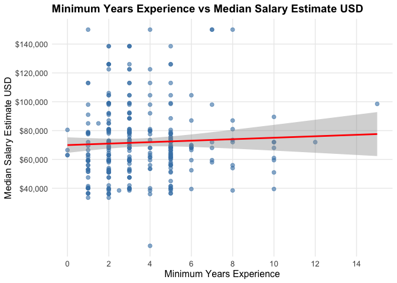

### 0.1.2 Experience vs. Salary Analysis

The scatter plot above shows the relationship between minimum years of experience required and median salary estimates. The red trend line indicates the general relationship between these variables.

```
## Categories in final data:
```

```
##
## neither       R  Python    both
##       0     199       0     108
```

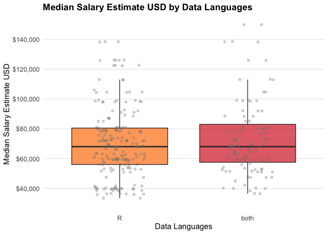

### 0.1.3 Programming Language Requirements and Salary

The box plot above shows the distribution of salary estimates across different programming language requirements. This visualization helps identify whether certain language combinations are associated with higher salary ranges.

| Language Requirements | Count | Mean Salary | Median Salary | Mean Experience (Years) |
| --- | --- | --- | --- | --- |
| R | 199 | 70771 | 68000 | 4 |
| both | 108 | 73524 | 68000 | 3 |

### 0.1.4 Summary Statistics

The table above provides detailed summary statistics for each programming language category, showing the count of jobs, mean and median salaries, and average years of experience required.

*Note: This analysis is based on job posting data. Language requirements were inferred from job descriptions using keyword matching. Salary estimates represent median values as reported in the job postings.*